# Visualising High-Dimensional Data

*A brief demo of how and why to use **t-SNE** for feature reduction and plotting.*

[figure not shown]

**Jonathan Sedar**

- Consulting Data Scientist
- Applied AI Ltd
- @jonsedar
- applied.ai

[figure not shown]

#### Applied AI Internal Demo Project

## HighDim DataViz Demo

Demo of high dimensional data visualisation with t-distributed Stochastic Neighbor Embedding (t-SNE)

- Using the [Urban Land Cover Classification](https://archive.ics.uci.edu/ml/datasets/Urban+Land+Cover) dataset from the UCI Machine Learning Repository.
- This content is available on our blog at http://blog.applied.ai/visualising-high-dimensional-data/

The **motivation** is to:

1. find and prepare a suitable high-dimensional dataset
2. demonstrate why the raw data can be hard to visually interpret
3. explain the basics of t-SNE
4. run t-SNE to reduce the dataset to 2 dimensions
5. plot and interpret

Note: this presentation is made using RISE, an in-development project to display a live Jupyter Notebook in reveal.js presentation form.

*Let me know if you notice anything buggy.*

# Contents

##### Abbreviated Contents

# Data Description

Using the [Urban Land Cover Classification](https://archive.ics.uci.edu/ml/datasets/Urban+Land+Cover) dataset from the UCI Machine Learning Repository.

#### We're dealing with Aerial / Satellite imagery

[figure not shown]

#### Combined with ground-truth classifications and subdivided into chunks of land

[figure not shown]

Size and shape features

```
brdindx:    Border Index    (shape)
area:       Area in m2      (size)
round:      Roundness       (shape)
compact:    Compactness     (shape)
shpIndx:    Shape Index     (shape)

lw:         Length/Width    (shape)
rect:       Rectangularity  (shape)
dens:       Density         (shape)
assym:      Assymetry       (shape)
bordlngth:  Border Length   (shape)
```

Spectral and texture features

```
bright:   Brightness            (spectral)
mean_G:   Green                 (spectral)
mean_R:   Red                   (spectral)
mean_NIR: Near Infrared         (spectral)
ndvi:     Nrmlzd Diff. Veg. Idx (spectral)

sd_g:     Std dev of Green      (texture)
sd_r:     Std dev of Red        (texture)
sd_nir:   Std dev of Near IR    (texture)
glcm1:    Gray-Level Co-occurrence Mx (texture)
glcm2:    Gray-Level Co-occurrence Mx (texture)
glcm3:    Gray-Level Co-occurrence Mx (texture)
```

And of course, the land classification

```
class: Land Class (id)
```

### Load from DB and take a look

```python
df = pd.read_sql('select * from df_clean', cnx)
print(df.shape)
df.head()
```

```
(675, 148)
```

|  | class | brdindx | area | round | bright | compact | shpindx | mean_g | mean_r | mean_nir | ... | sd_nir_140 | lw_140 | glcm1_140 | rect_140 | glcm2_140 | dens_140 | assym_140 | ndvi_140 | bordlngth_140 | glcm3_140 |
| --- | --- | --- | --- | --- | --- | --- | --- | --- | --- | --- | --- | --- | --- | --- | --- | --- | --- | --- | --- | --- | --- |
| 0 | car | 1.27 | 91 | 0.97 | 231.38 | 1.39 | 1.47 | 207.92 | 241.74 | 244.48 | ... | 26.18 | 2.00 | 0.50 | 0.85 | 6.29 | 1.67 | 0.70 | -0.08 | 56 | 3806.36 |
| 1 | concrete | 2.36 | 241 | 1.56 | 216.15 | 2.46 | 2.51 | 187.85 | 229.39 | 231.20 | ... | 22.29 | 2.25 | 0.79 | 0.55 | 8.42 | 1.38 | 0.81 | -0.09 | 1746 | 1450.14 |
| 2 | concrete | 2.12 | 266 | 1.47 | 232.18 | 2.07 | 2.21 | 206.54 | 244.22 | 245.79 | ... | 15.59 | 2.19 | 0.76 | 0.74 | 7.24 | 1.68 | 0.81 | -0.07 | 566 | 1094.04 |
| 3 | concrete | 2.42 | 399 | 1.28 | 230.40 | 2.49 | 2.73 | 204.60 | 243.27 | 243.32 | ... | 13.51 | 3.34 | 0.82 | 0.74 | 7.44 | 1.36 | 0.92 | -0.09 | 1178 | 1125.38 |
| 4 | concrete | 2.15 | 944 | 1.73 | 193.18 | 2.28 | 4.10 | 165.98 | 205.55 | 208.00 | ... | 15.65 | 50.08 | 0.85 | 0.49 | 8.15 | 0.23 | 1.00 | -0.08 | 6232 | 1146.38 |

5 rows × 148 columns

## Initial Views: Group Sizes & Distributions

After import we should take a very quick look at the basic group sizes and distributions

### Class group sizes

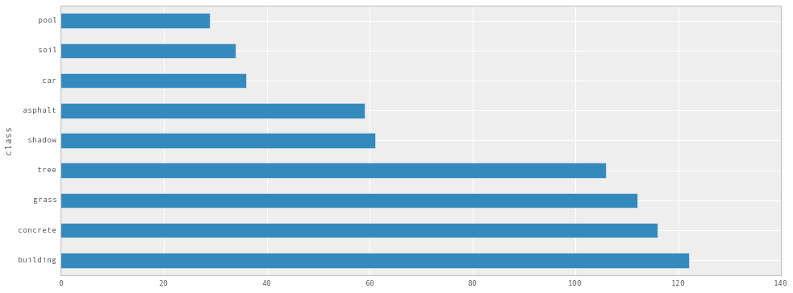

```python
ax = df.groupby('class').size().order()[::-1].plot(
    kind='barh', figsize=(16,6))
```

- Most of our 675 land chunks are `building`, `concrete`, `grass` or `tree`
- The under-represented classes are `car`, `soil` & `pool`

### 1-Dimensional Distributions

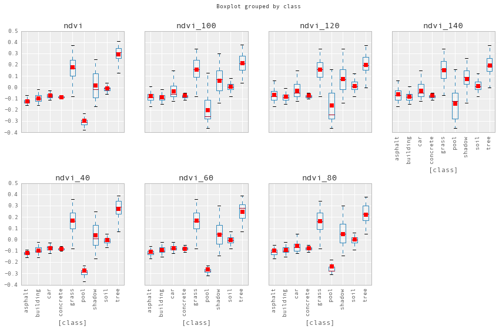

```python
interactive(plot_raw_vals, df=fixed(df), k=basic)
```

# Feature Reduction

## Check for degeneracy and compressability (scipy svd method)

```python
# standardize
scaler = StandardScaler().fit(df.iloc[:,1:])
dfs = pd.DataFrame(scaler.transform(df.iloc[:,1:]), index=df.index, columns=df.columns[1:])

# use scipy truncated SVD from both ends and concat back together
u1, s1, vt1 = svds(dfs, k=int(np.ceil(dfs.shape[1]/2)), which='LM')
u2, s2, vt2 = svds(dfs, k=int(np.floor(dfs.shape[1]/2)), which='SM')
u = np.concatenate((u2,u1), axis=1)[:,::-1]
s = np.concatenate((s2,s1), axis=0)[::-1]
vt = np.concatenate((vt2,vt1), axis=0)[:,::-1]

# Are any eigenvalues NaN or really small?
print('{} SVs are NaN'.format(np.isnan(s).sum()))
print('{} SVs less than 1e-12'.format(len(s[s < 1e-12])))
```

```
0 SVs are NaN
0 SVs less than 1e-12
```

**Observe**: Okay good, we seem so to have no outright degeneracy

## View explained variance

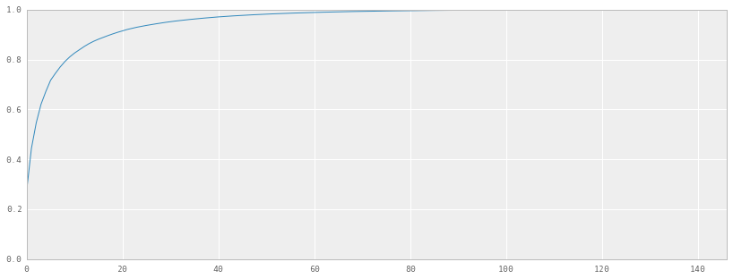

```python
idx = ~np.isnan(s)
xtrans = np.dot(u[:,idx], np.diag(s[idx]))
expvar = np.var(xtrans, axis=0)
fullvar = np.var(dfs, axis=0)
expvarrat = expvar/fullvar.sum()
ax = pd.Series(expvarrat.cumsum()).plot(kind='line', figsize=(14,5)).set_ylim([0,1])
```

**Observe**: It seems like we can compress the 147 original features into ~80 components (eigenvectors) without loss of variance!

## Feature Reduction (using scikit-learn Truncated-SVD)

We'll use the `TruncatedSVD` method in the `scikit-learn` package to transform the full dataset into a representation using the top 100 components, thus preserving variance in the data but using fewer dimensions to do so.

This has a very similar effect to [Principal Component Analysis](https://en.wikipedia.org/wiki/Principal_component_analysis) (PCA) where we represent the original data using an orthogonal set of axes rotated and aligned to the variance in the dataset.

Truncated-SVD is a [quicker calculation](https://en.wikipedia.org/wiki/Singular_value_decomposition#Reduced_SVDs), and using `scikit-learn` is more convenient and consistent with our usage elsewhere.

**Note:** there's nothing special about using the top 100 components, it's just a nice round number which preserves a lot of variance and is still too large to easily visualise, necessitating our using t-SNE.

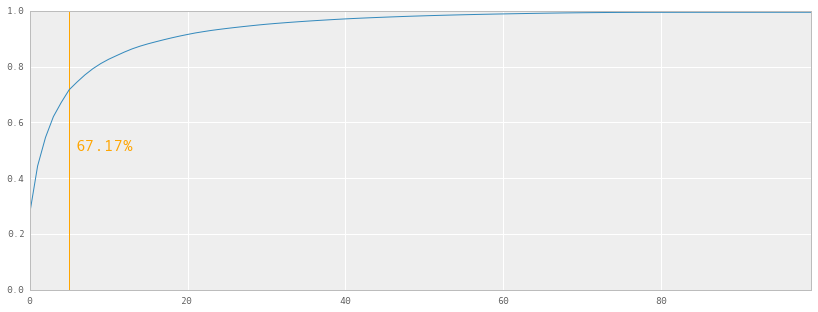

```python
ncomps = 100
svd = TruncatedSVD(n_components=ncomps)
svd_fit = svd.fit(dfs)
Y = svd.fit_transform(dfs)
ax = pd.Series(svd_fit.explained_variance_ratio_.cumsum()).plot(
    kind='line', figsize=(14,5))
_ = ax.vlines(5,0,1,'orange')
_ = ax.annotate('{:.2%}'.format(svd_fit.explained_variance_ratio_.cumsum()[4])
                ,xy=(6,0.5), xycoords='data', color='orange', fontsize=16)
```

**Observe**: This is quite a compressable dataset, we *could* choose to retain ~67% variance using only 5 features

# Basic Visualisation

Now that we have a compressed dataset, represented by the top 100 components of an SVD, lets attempt to visualise the data:

## Pairs Plots

Using the first few components

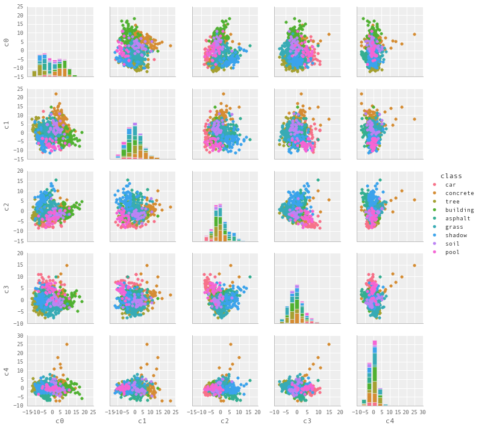

```python
ax = sns.pairplot(dfsvdplot.iloc[::1,:], hue='class', size=2)
```

##### Observe:

Datapoints from the same land usage classes tend to cluster together

Distinct classes on different sides of the plots, e.g.

- `building` is far from `tree` along the `c0` component
- `concrete` is far from `shadow` along the `c1` component

However, this pairs-plot suffers several issues:

- 5x5 components only shows 67% of full variance
- Showing more components e.g. 10x10 unworkable
- Reader must comparisons in their head while viewing
- Classes with lower counts e.g. `car` and `pool` are hard to see

## 3D Scatterplot

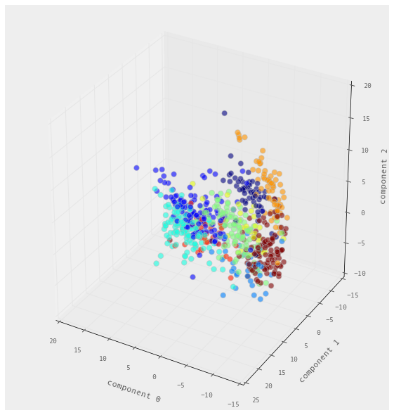

```python
interactive(plot_3d_scatter, A=fixed(dfsvd), elevation=30, azimuth=120, max_pts=fixed(1000))
```

##### Observe:

- `ipywidgets` interactive controls for elevation and azimuth
- Viewing top components in 3D is slightly useful
- Still suffer from the major limitations of the pairs-plots
- Lose a lot of the variance
- Have to hold a lot in our heads when viewing.

Clearly need a better way to visualise the 675 datapoints and their 100 dimensions

# t-SNE Visualisation

Ready to discuss t-Distributed Stochastic Neighbor Embedding (t-SNE)

- t-SNE is a probabilistic technique for dimensionality reduction (aka manifold learning)
- Primary use is for visualisation
- Developed by [Laurens van der Maaten](https://lvdmaaten.github.io/) and [Geoffery Hinton](http://www.cs.toronto.edu/~hinton/) and [first published](https://lvdmaaten.github.io/publications/papers/JMLR_2008.pdf) in 2008
- The main resource for theoretical detail (papers, talks etc) is https://lvdmaaten.github.io/tsne/.

## Basic theory

*Create a 'good' 2D repr of data originally described in $d$ dimensions.*

**First:** Build a probabilistic repr. of the full dimensional manifold:

- Measure pairwise affinity (euclidian distance) between all datapoints $X = \{x_{1}, x_{2}, x_{n}\}$ in full $d$ dimensions
- Record affinities as cond. probs. $p_{j|i}$ using a **Gaussian kernel**
  - i.e. the prob. of $x_{i}$ having $x_{j}$ as it's nearest neighbor
- For close neighbors, $p_{j|i}$ is higher than for distant ones
- Combine all probs. into a joint prob. dist. $P = \sum_{i}\sum_{j}p_{j|i}$

**Second** Build a probabilistic repr of a 2D manifold:

- Use PCA to represent datapoints using top 2 components
- Measure pairwise affinity (euclidian distance) between all datapoints $Y = \{y_{1}, y_{2}, y_{n}\}$ in 2D
- Record distances as cond. probs. $q_{j|i}$ etc using a **Student t-Distributed kernel**
  - i.e. the prob. of $y_{i}$ having $y_{j}$ as it's nearest neighbor
- Combine all probs into a joint prob. dist. $Q = \sum_{i}\sum_{j}q_{j|i}$

If $Y$ were a perfect map of $X$, then $P \approx Q$

...unlikely if $d >> 2$

So we minimise the distance between $P$ and $Q$:

- Measure the cost function of KL-Divergence $C= KL(P||Q)$
- Use stochastic gradient descent to minimise $C$, aka peturb the distribution of $Y$ (and therefore $Q$) until $C$ converges

More detail:

- KL is non-symmetric: $C$ is lower for distant points in $X$, so it preserves locality
- Tuneable (variance of Gaussian kernel, perplexity, momentum, noise variance, learning rate)
- Additional tricks: early compression (L2-penalty on $C$), early exaggeration (force $p_{ij}$ too large)

The result is a 2D representation that quite accurately preserves local distances, so grouping in $d$ becomes apparent

Alternatives include Isomap, Multi-Dimensional Scaling, Locally Linear Embedding (all of which available in [scikit-learn](http://scikit-learn.org/stable/modules/manifold.html)) and [Topological Data Analysis](http://www.dyinglovegrape.com/math/topology_data_1.php).

## Fit and plot t-SNE

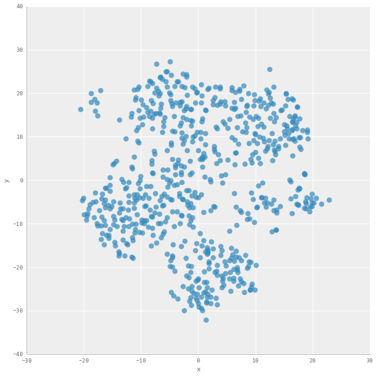

```python
ax = sns.lmplot('x', 'y', dftsne, fit_reg=False, size=9, scatter_kws={'alpha':0.7,'s':80})
```

##### Observe:

- This is promising... top 100 SVD components -> 2 dimensions and we can clearly see clusters of datapoints.

When doing unsupervised learning (without class labels) we might expect to get this far and then backtrack to run clustering algorithms in the 100 dimensional space.

Now let's view the t-SNE representation with land classification class labels...

# View t-SNE plot with class labels

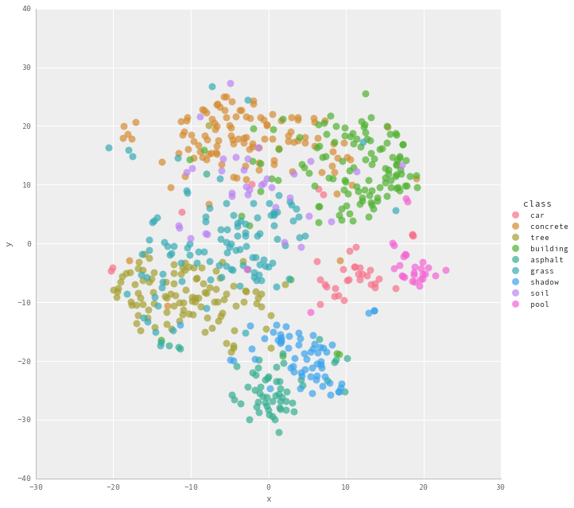

```python
g = sns.lmplot('x', 'y', dftsne, hue='class', fit_reg=False, size=9, scatter_kws={'alpha':0.7,'s':80})
```

##### Observe

With class labels added we can clearly see the clustering of land classes

- Again we see `building` as a very distinct cluster from `tree`
- but now also as distinct from `asphalt`, `shadow`, `grass`, `car` and `pool`

Now we can start to see similarities in classes, e.g.

- `shadow` and `asphalt` (dark on the images?)
- `car` and `pool` (high reflectance and small area?)
- `tree` and `grass` (vegetation with similar red & IR absorption?)

# Summary

We have sourced and prepared a small but high-dimensional dataset:

- Difficulty of visualising the raw data
- Benefits of using feature reduction (degeneracy / redundancy)
- Difficulty of visualising even the prepared data in 2D & 3D

We have demonstrated using t-SNE to:

- Create a low-dim representation of the high-dim data
- Visualise the structure with class clusters easily seen.

# Thank You

[figure not shown]

**Jonathan Sedar**

- Consulting Data Scientist
- Applied AI Ltd
- @jonsedar
- applied.ai

This content is available on our blog at http://blog.applied.ai/visualising-high-dimensional-data/